# EasyVisa Project

### Bivariate Analysis

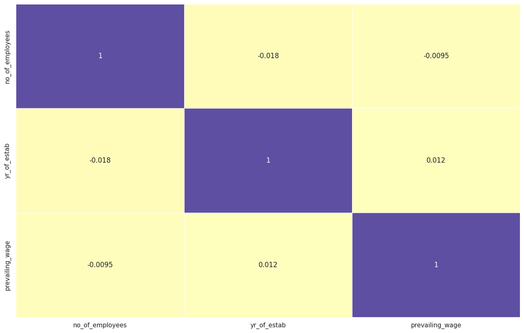

```python
# correlation grid for numerical categories
sns.set(rc={'figure.figsize':(16,10)})
sns.heatmap(data.corr(),
            annot=True,
            linewidths=.5,
            center=0,
            cbar=False,
            cmap="Spectral")
plt.show()
```

- There is no correlation between numerical categories.

```python
### function to plot distributions wrt target


def distribution_plot_wrt_target(data, predictor, target):

    fig, axs = plt.subplots(2, 2, figsize=(12, 10))

    target_uniq = data[target].unique()

    axs[0, 0].set_title("Distribution of target for target=" + str(target_uniq[0]))
    sns.histplot(
        data=data[data[target] == target_uniq[0]],
        x=predictor,
        kde=True,
        ax=axs[0, 0],
        color="teal",
        stat="density",
    )

    axs[0, 1].set_title("Distribution of target for target=" + str(target_uniq[1]))
    sns.histplot(
        data=data[data[target] == target_uniq[1]],
        x=predictor,
        kde=True,
        ax=axs[0, 1],
        color="orange",
        stat="density",
    )

    axs[1, 0].set_title("Boxplot w.r.t target")
    sns.boxplot(data=data, x=target, y=predictor, ax=axs[1, 0], palette="gist_rainbow")

    axs[1, 1].set_title("Boxplot (without outliers) w.r.t target")
    sns.boxplot(
        data=data,
        x=target,
        y=predictor,
        ax=axs[1, 1],
        showfliers=False,
        palette="gist_rainbow",
    )

    plt.tight_layout()
    plt.show()
```

```python
def stacked_barplot(data, predictor, target):
    """
    Print the category counts and plot a stacked bar chart

    data: dataframe
    predictor: independent variable
    target: target variable
    """
    count = data[predictor].nunique()
    sorter = data[target].value_counts().index[-1]
    tab1 = pd.crosstab(data[predictor], data[target], margins=True).sort_values(
        by=sorter, ascending=False
    )
    print(tab1)
    print("-" * 120)
    tab = pd.crosstab(data[predictor], data[target], normalize="index").sort_values(
        by=sorter, ascending=False
    )
    tab.plot(kind="bar", stacked=True, figsize=(count + 5, 5))
    plt.legend(
        loc="lower left", frameon=False,
    )
    plt.legend(loc="upper left", bbox_to_anchor=(1, 1))
    plt.show()
```

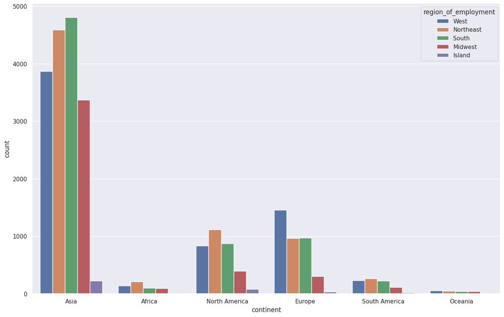

```python
# countplot of continent and region of employment
sns.countplot(data=data, x='continent', hue='region_of_employment');
```

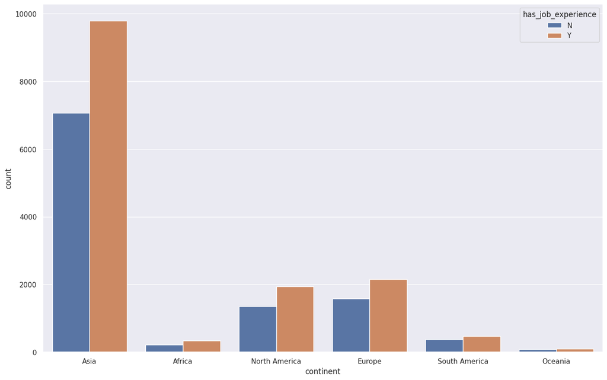

```python
# countplot of continent and has_job_experience
sns.countplot(data=data, x='continent', hue='has_job_experience');
```

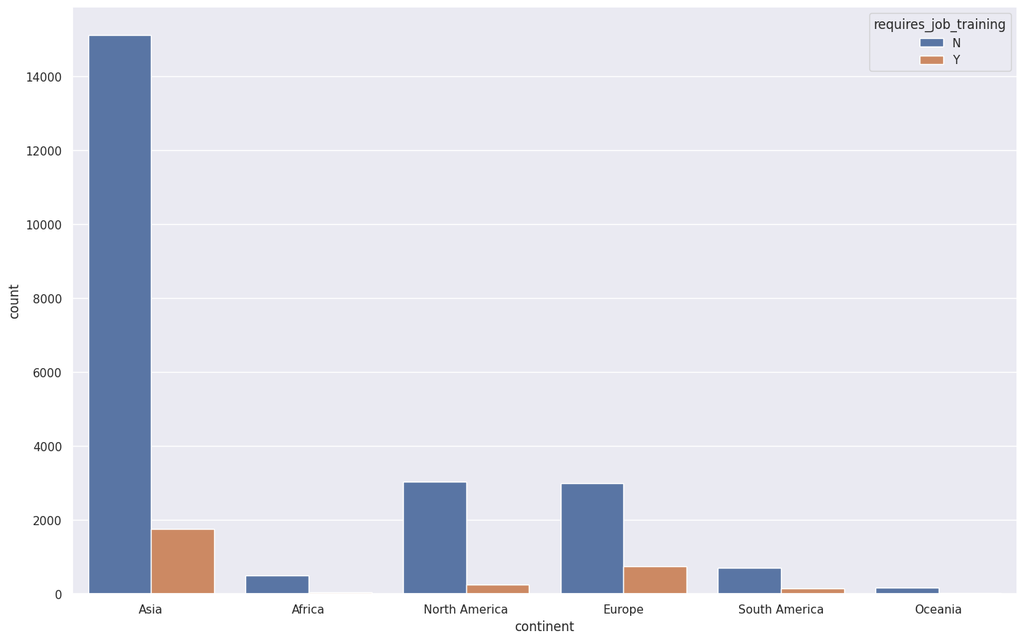

```python
# countplot of continent and requires_job_training
sns.countplot(data=data, x='continent', hue='requires_job_training');
```

**Leading Questions**:

1. Those with higher education may want to travel abroad for a well-paid job. Does education play a role in Visa certification?

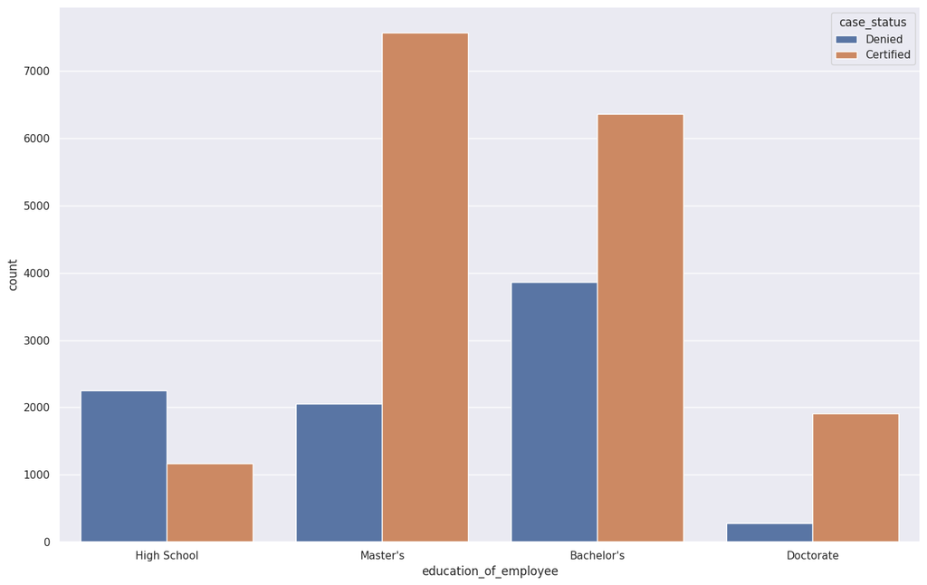

```python
# countplot of education_of_employee and case_status
sns.countplot(data=data, x='education_of_employee', hue='case_status', );
```

```
case_status            Certified  Denied    All
education_of_employee
All                        17018    8462  25480
Bachelor's                  6367    3867  10234
High School                 1164    2256   3420
Master's                    7575    2059   9634
Doctorate                   1912     280   2192
------------------------------------------------------------------------------------------------------------------------
```

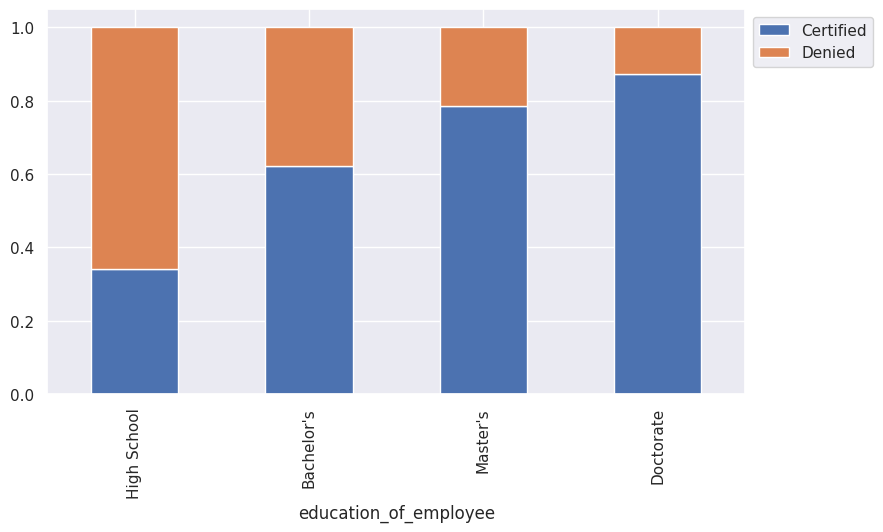

```python
# stacked barplot for education_of_employee and case_status
stacked_barplot(data, "education_of_employee", "case_status")
```

- Education seemingly plays a role in 'case_status.'
- Obtaining a High School diploma potentially contributed to a ~34.04% approval rate.
- Obtaining a Bachelor's potentially contributed to a 62.21% approval rate.
- Obtaining a Master's potentially contributed to a 78.63% approval rate.
- Obtaining a Doctorate potentially contributed to an 87.23% approval rate.
1. How does the visa status vary across different continents?

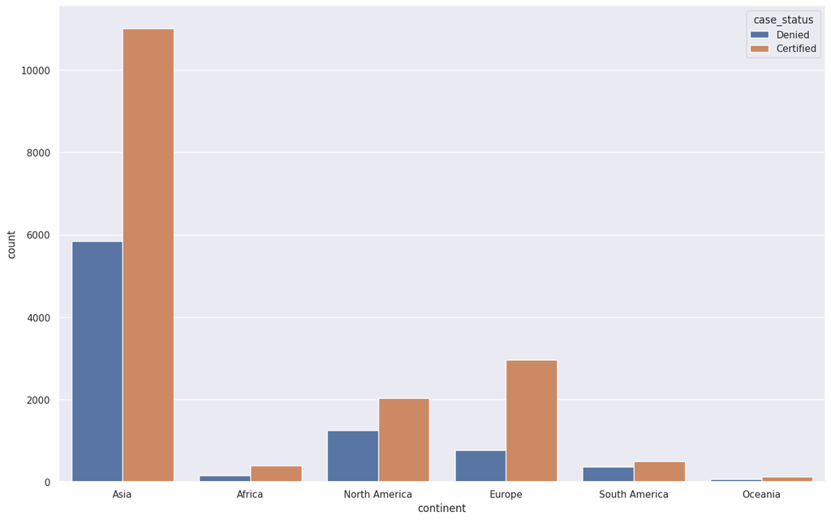

```python
# countplot of continent and case_status
sns.countplot(data=data, x='continent', hue='case_status');
```

Visa status for top 3 continents:

- Asia: ~11,000 certified, ~5,800 denied
- Europe: ~3,000 certified, ~800 denied
- North America: ~2,000, ~1,300 denied

```
case_status    Certified  Denied    All
continent
All                17018    8462  25480
Asia               11012    5849  16861
North America       2037    1255   3292
Europe              2957     775   3732
South America        493     359    852
Africa               397     154    551
Oceania              122      70    192
------------------------------------------------------------------------------------------------------------------------
```

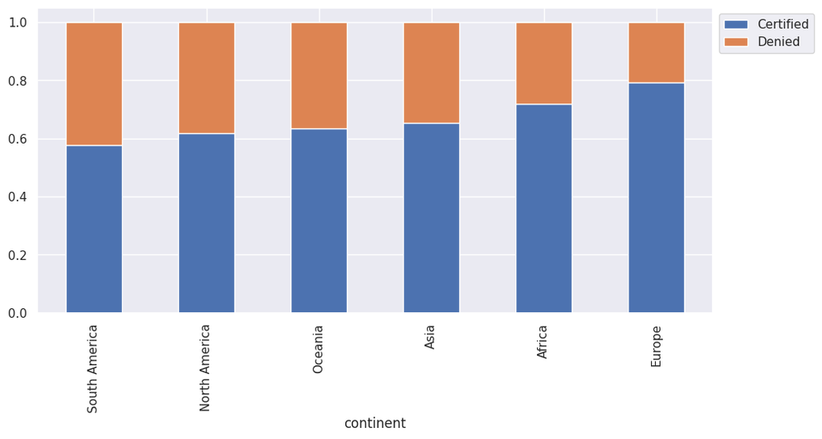

```python
# stacked barplot for continent and case_status
stacked_barplot(data, "continent", "case_status")
```

Visa status approval rate for top 3 continents:

- Asia: 65.31% approval rate
- Europe: 79.23% approval rate
- North America: 61.88% approval rate
1. Experienced professionals might look abroad for opportunities to improve their lifestyles and career development. Does work experience influence visa status?

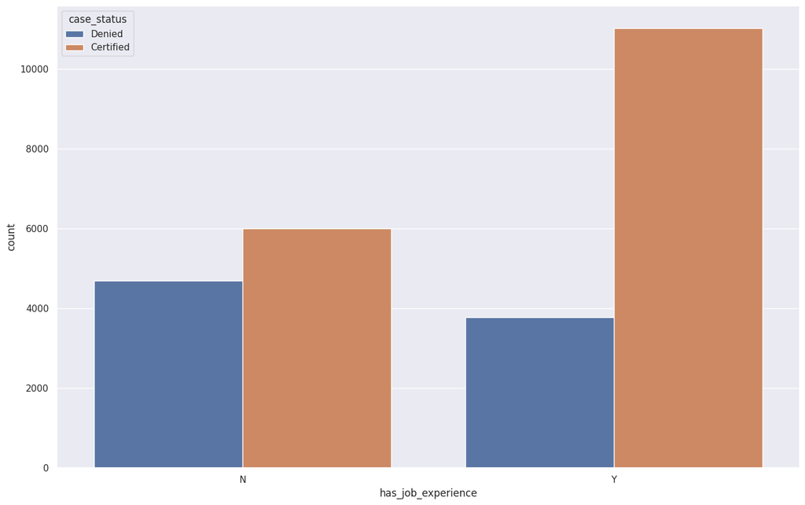

```python
# countplot of has_job_experience and case_status
sns.countplot(data=data, x='has_job_experience', hue='case_status');
```

```
case_status         Certified  Denied    All
has_job_experience
All                     17018    8462  25480
N                        5994    4684  10678
Y                       11024    3778  14802
------------------------------------------------------------------------------------------------------------------------
```

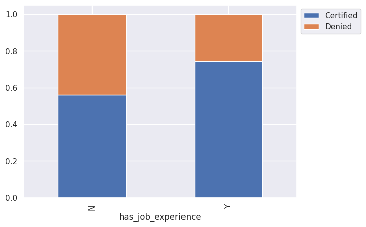

```python
# stacked barplot for has_job_experience and case_status
stacked_barplot(data, "has_job_experience", "case_status")
```

Visa status approval rate for job experience:

- Has Job Experience (Y): 74.48% approval rate
- Has No Job Experience (N): 56.13% approval rate
1. In the United States, employees are paid at different intervals. Which pay unit is most likely to be certified for a visa?

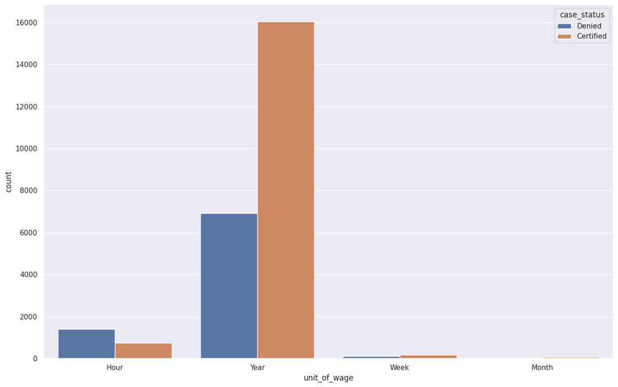

```python
# countplot of unit_of_wage and region of case_Status
sns.countplot(data=data, x='unit_of_wage', hue='case_status');
```

*The most likely pay unit to be certified is 'Year.'

Case Status by Unit of Wage:

```
case_status   Certified  Denied    All
unit_of_wage
All               17018    8462  25480
Year              16047    6915  22962
Hour                747    1410   2157
Week                169     103    272
Month                55      34     89
------------------------------------------------------------------------------------------------------------------------
```

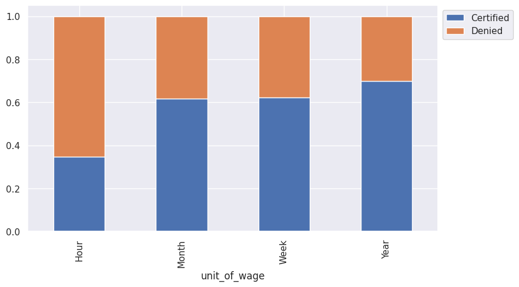

```python
# stacked barplot for unit_of_wage and case_status
stacked_barplot(data, "unit_of_wage", "case_status")
```

Visa status approval rate:

- Hour: 34.63% approval rate
- Week: 62.13% approval rate
- Month: 61.80% approval rate
- Year: 69.89% approval rate
1. The US government has established a prevailing wage to protect local talent and foreign workers. How does the visa status change with the prevailing wage?

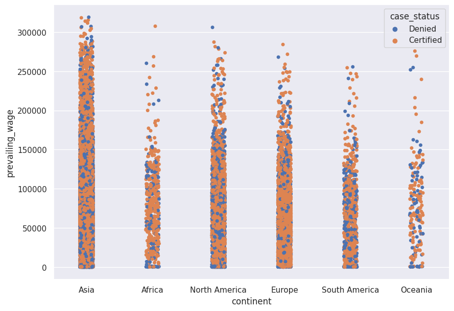

```python
# strip plot of continent and prevailing_wage classified by case_status
plt.figure(figsize=(10,7))
sns.stripplot(data=data, x='continent', y='prevailing_wage', hue='case_status', jitter=True);
```

- Visa status does not seem to be impacted by prevailing_wage.
- There is no overwhelming concentration of 'denied' or 'certified' status at any one particular prevailing_wage.

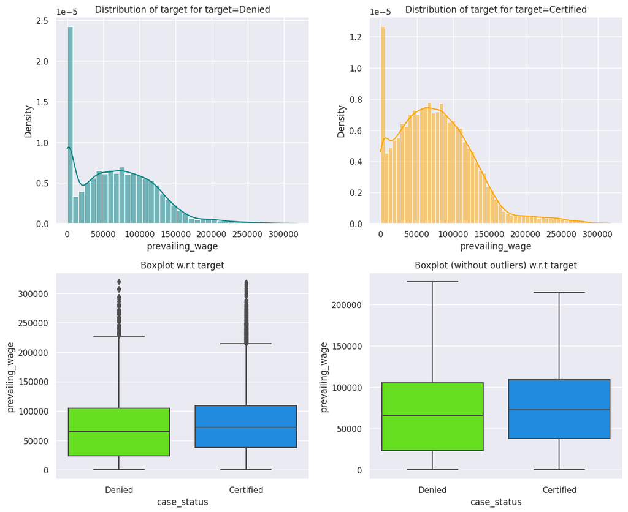

```python
# distribution plot of prevailing_wage and case_status
distribution_plot_wrt_target(data,'prevailing_wage', 'case_status')
```

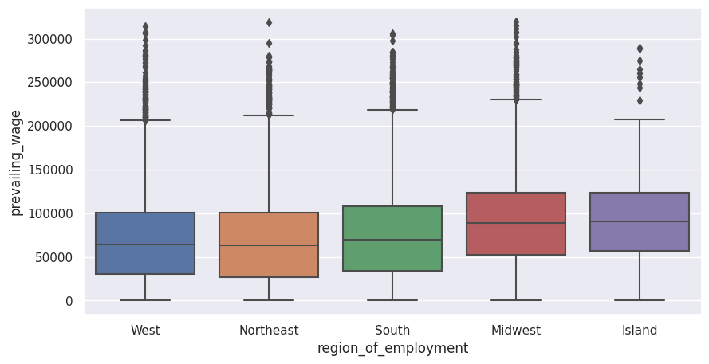

```python
# boxplot of region_of_employment and prevailing_wage
plt.figure(figsize=(10, 5))
sns.boxplot(data=data, x='region_of_employment', y='prevailing_wage')
plt.show()
```

## Data Preprocessing

- Missing value treatment (if needed)
- Outlier detection and treatment (if needed)
- Feature engineering
- Preparing data for modeling
- Any other preprocessing steps (if needed)

### Missing Value Treatment

- Not Applicable

### Outlier Detection and Treatment (if needed)

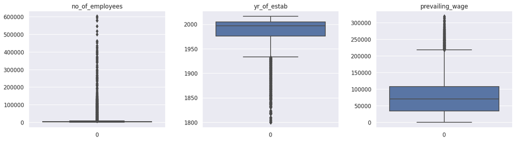

```python
# outlier detection using boxplot
numeric_columns = data.select_dtypes(include=np.number).columns.tolist()


plt.figure(figsize=(15, 12))

for i, variable in enumerate(numeric_columns):
    plt.subplot(3, 3, i + 1)
    sns.boxplot(data[variable], whis=1.5)
    plt.tight_layout(pad=2)
    plt.title(variable)
plt.show()
```

- There are several outliers present, but it is correct information, nonetheless.

```python
# functions to treat outliers through capping and flooring

def treat_outliers(df, col):
    """
    Treats outliers in a variable

    df: dataframe
    col: dataframe column
    """
    Q1 = df[col].quantile(0.25)  # 25th quantile
    Q3 = df[col].quantile(0.75)  # 75th quantile
    IQR = Q3 - Q1
    Lower_Whisker = Q1 - 1.5 * IQR
    Upper_Whisker = Q3 + 1.5 * IQR

    # all the values smaller than Lower_Whisker will be assigned the value of Lower_Whisker
    # all the values greater than Upper_Whisker will be assigned the value of Upper_Whisker
    df[col] = np.clip(df[col], Lower_Whisker, Upper_Whisker)

    return df


def treat_outliers_all(df, col_list):
    """
    Treat outliers in a list of variables

    df: dataframe
    col_list: list of dataframe columns
    """
    for c in col_list:
        df = treat_outliers(df, c)

    return df
```

```python
# to treat outliers through capping and flooring
numerical_col = data.select_dtypes(include=np.number).columns.tolist()
data = treat_outliers_all(data, numerical_col)
```

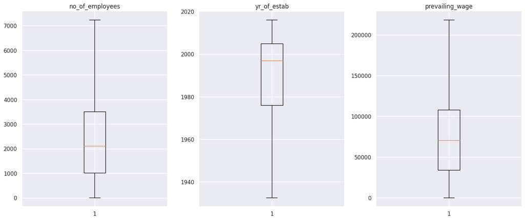

```python
# to view treated numerical columns after capping and flooring
plt.figure(figsize=(20, 30))

for i, variable in enumerate(numerical_col):
    plt.subplot(5, 4, i + 1)
    plt.boxplot(data[variable], whis=1.5)
    plt.tight_layout()
    plt.title(variable)

plt.show()
```

- The maximum number of employees at an employer with a candidate is ~7,200.
- The minimum year of establishment for an employer is before 1940.
- The maximum prevailing wage for a candidate is ~$220,000.

### Preparing data for modeling

```python
# to encode categorical features
data["case_status"] = data["case_status"].apply(lambda x: 1 if x == "Certified" else 0)
```

```python
# to drop case_status from data
X = data.drop(['case_status'], axis=1)
Y = data["case_status"]
```

- Drop case_status as we would not have case_status while predicting new observations.

```python
# to add a constant to the independent variables
X = sm.add_constant(X)
```

```python
# creating dummy variables
X = pd.get_dummies(X, drop_first=True)
```

```python
# splitting data in train and test sets
X_train, X_test, y_train, y_test = train_test_split(
    X, Y, test_size=0.30, random_state=1, shuffle=True
)
```

```python
# printing training and test set data
print("Shape of Training set : ", X_train.shape)
print("Shape of test set : ", X_test.shape)
print("Percentage of classes in training set:")
print(y_train.value_counts(normalize=True))
print("Percentage of classes in test set:")
print(y_test.value_counts(normalize=True))
```

```
Shape of Training set :  (17836, 22)
Shape of test set :  (7644, 22)
Percentage of classes in training set:
1   0.66360
0   0.33640
Name: case_status, dtype: float64
Percentage of classes in test set:
1   0.67792
0   0.32208
Name: case_status, dtype: float64
```

- The training set and the test set are very close to a 70:30 for more reliable data analysis.

### Any other preprocessing steps (if needed)

- Fitting Different Models on the train data
- Attempt to Improve Performance by tuning hyperparameters

## Building a Logistic Regression model

```python
# function to compute different metrics to check performance of a classification model built using statsmodels
def model_performance_classification_statsmodels(
    model, predictors, target, threshold=0.5
):
    """
    Function to compute different metrics to check classification model performance

    model: classifier
    predictors: independent variables
    target: dependent variable
    threshold: threshold for classifying the observation as class 1
    """

    # checking which probabilities are greater than threshold
    pred_temp = model.predict(predictors) > threshold
    # rounding off the above values to get classes
    pred = np.round(pred_temp)
# to compute Accuracy
    acc = accuracy_score(target, pred)
# to compute Recall
    recall = recall_score(target, pred)
# to compute Precision
    precision = precision_score(target, pred)
# to compute F1-score
    f1 = f1_score(target, pred)

# creating a dataframe of metrics
    df_perf = pd.DataFrame(
        {"Accuracy": acc, "Recall": recall, "Precision": precision, "F1": f1,},
        index=[0],
    )

    return df_perf
```

```python
# defining a function to plot the confusion_matrix of a classification model
def confusion_matrix_statsmodels(model, predictors, target, threshold=0.5):
    """
    To plot the confusion_matrix with percentages

    model: classifier
    predictors: independent variables
    target: dependent variable
    threshold: threshold for classifying the observation as class 1
    """
    y_pred = model.predict(predictors) > threshold
    cm = confusion_matrix(target, y_pred)
    labels = np.asarray(
        [
            ["{0:0.0f}".format(item) + "\n{0:.2%}".format(item / cm.flatten().sum())]
            for item in cm.flatten()
        ]
    ).reshape(2, 2)

    plt.figure(figsize=(6, 4))
    sns.heatmap(cm, annot=labels, fmt="")
    plt.ylabel("True label")
    plt.xlabel("Predicted label")
```

```python
# to fit logistic regression model
logit = sm.Logit(y_train, X_train.astype(float))
lg = logit.fit(maxiter=500)

print(lg.summary())
```

```
Optimization terminated successfully.
         Current function value: 0.533047
         Iterations 6
                           Logit Regression Results
==============================================================================
Dep. Variable:            case_status   No. Observations:                17836
Model:                          Logit   Df Residuals:                    17814
Method:                           MLE   Df Model:                           21
Date:                Sat, 21 Oct 2023   Pseudo R-squ.:                  0.1653
Time:                        06:29:13   Log-Likelihood:                -9507.4
converged:                       True   LL-Null:                       -11390.
Covariance Type:            nonrobust   LLR p-value:                     0.000
=====================================================================================================
                                        coef    std err          z      P>|z|      [0.025      0.975]
-----------------------------------------------------------------------------------------------------
const                                -2.5266      1.379     -1.832      0.067      -5.230       0.177
no_of_employees                    1.639e-05   9.63e-06      1.701      0.089   -2.49e-06    3.53e-05
yr_of_estab                           0.0005      0.001      0.697      0.486      -0.001       0.002
prevailing_wage                    4.136e-07   4.04e-07      1.025      0.306   -3.78e-07     1.2e-06
continent_Asia                       -0.3098      0.133     -2.327      0.020      -0.571      -0.049
continent_Europe                      0.4309      0.142      3.036      0.002       0.153       0.709
continent_North America              -0.3824      0.140     -2.734      0.006      -0.657      -0.108
continent_Oceania                    -0.2279      0.236     -0.964      0.335      -0.691       0.235
continent_South America              -0.5133      0.161     -3.187      0.001      -0.829      -0.198
education_of_employee_Doctorate       1.3336      0.084     15.941      0.000       1.170       1.498
education_of_employee_High School    -1.3504      0.053    -25.381      0.000      -1.455      -1.246
education_of_employee_Master's        0.8628      0.042     20.717      0.000       0.781       0.944
has_job_experience_Y                  0.9414      0.037     25.683      0.000       0.870       1.013
requires_job_training_Y               0.1020      0.058      1.767      0.077      -0.011       0.215
region_of_employment_Midwest          0.8864      0.147      6.048      0.000       0.599       1.174
region_of_employment_Northeast        0.2102      0.143      1.471      0.141      -0.070       0.490
region_of_employment_South            0.5942      0.143      4.142      0.000       0.313       0.875
region_of_employment_West             0.0043      0.143      0.030      0.976      -0.276       0.285
unit_of_wage_Month                    0.9123      0.301      3.030      0.002       0.322       1.502
unit_of_wage_Week                     0.9395      0.177      5.298      0.000       0.592       1.287
unit_of_wage_Year                     1.2343      0.071     17.458      0.000       1.096       1.373
full_time_position_Y                  0.2522      0.061      4.162      0.000       0.133       0.371
=====================================================================================================
```

- P-Value of a variable indicates if the variable is significant or not. If we consider the significance level to be 0.05 (5%), then any variable with a p-value less than 0.05 would be considered significant.
  - no_of_employees: P-Value= 0.089
  - yr_of_estab: P-Value= 0.486
  - prevailing_wage: P-Value= 0.306
- Positive values of the coefficient show that the probability of a candidate being certified increases with the increase of the corresponding attribute value.
  - no_of_employees: coef= 1.639e-05
  - yr_of_estab: coef= 0.0005
  - prevailing_wage: coef= 4.136e-07
- Negative values of the coefficient show that the probability of a candidate being certified decreases with the decrease of the corresponding attribute value.
  - N/A for relevant variables

```python
print("Training performance:")
model_performance_classification_statsmodels(lg, X_train, y_train)
```

```
Training performance:
```

|  | Accuracy | Recall | Precision | F1 |
| --- | --- | --- | --- | --- |
| 0 | 0.73767 | 0.87724 | 0.76295 | 0.81611 |

- Training Performance:
  - Accuracy: 73.77%
  - Recall: 87.72%
  - Precision: 76.30%
  - F1: 81.61%
- The relatively high rate of Recall may be a cause for concern. More testing for multicollinearity and potential pruning may reflect a more reliable model.

## Checking Multicollinearity

- In order to make statistical inferences from a logistic regression model, it is important to ensure that there is no multicollinearity present in the data.

```python
def checking_vif(predictors):
    vif = pd.DataFrame()
    vif["feature"] = predictors.columns

    # calculating VIF for each feature
    vif["VIF"] = [
        variance_inflation_factor(predictors.values, i)
        for i in range(len(predictors.columns))
    ]
    return vif
```

```python
# checking VIF on training data
checking_vif(X_train)
```

|  | feature | VIF |
| --- | --- | --- |
| 0 | const | 6023.77266 |
| 1 | no_of_employees | 1.01293 |
| 2 | yr_of_estab | 1.00483 |
| 3 | prevailing_wage | 1.35639 |
| 4 | continent_Asia | 10.96031 |
| 5 | continent_Europe | 6.79247 |
| 6 | continent_North America | 6.30744 |
| 7 | continent_Oceania | 1.36936 |
| 8 | continent_South America | 2.53379 |
| 9 | education_of_employee_Doctorate | 1.16247 |
| 10 | education_of_employee_High School | 1.16516 |
| 11 | education_of_employee_Master's | 1.26358 |
| 12 | has_job_experience_Y | 1.04762 |
| 13 | requires_job_training_Y | 1.07551 |
| 14 | region_of_employment_Midwest | 10.06916 |
| 15 | region_of_employment_Northeast | 14.17529 |
| 16 | region_of_employment_South | 13.88717 |
| 17 | region_of_employment_West | 13.57100 |
| 18 | unit_of_wage_Month | 1.04891 |
| 19 | unit_of_wage_Week | 1.15980 |
| 20 | unit_of_wage_Year | 1.52556 |
| 21 | full_time_position_Y | 1.12244 |

### Dropping high p-value variables (if needed)

- We will drop the predictor variables having a p-value greater than 0.05 as they do not significantly impact the target variable.
- But sometimes p-values change after dropping a variable. So, we'll not drop all variables at once.
- Instead, we will do the following:
  - Build a model, check the p-values of the variables, and drop the column with the highest p-value.
  - Create a new model without the dropped feature, check the p-values of the variables, and drop the column with the highest p-value.
  - Repeat the above two steps till there are no columns with p-value > 0.05.

The above process can also be done manually by picking one variable at a time that has a high p-value, dropping it, and building a model again. But that might be a little tedious and using a loop will be more efficient.

```python
# to check for p-values on the right dataset
predictors = X_train.copy()

# initial list of columns
cols = X_train.columns.tolist()

# setting an initial max p-value
max_p_value = 1

while len(cols) > 0:

# defining the train set
    x_train_aux = X_train[cols]

# fitting the model
    model = sm.Logit(y_train, x_train_aux).fit(disp=False)

# getting the p-values and the maximum p-value
    p_values = model.pvalues
    max_p_value = max(p_values)

# name of the variable with maximum p-value
    feature_with_p_max = p_values.idxmax()

    if max_p_value > .05:
        cols.remove(feature_with_p_max)
    else:
        break

selected_features = cols
print(selected_features)
```

[output not shown]

```python
# to specify the train data from which to select the specified columns
X_train1 = X_train[selected_features]

# to specify the test data from which to select the specified columns
X_test1 = X_test[selected_features]
```

```python
# to train logistic regression X_train1 and y_train
logit2= sm.Logit(y_train, X_train1)

# to fit logistic regression
lg2 = logit2.fit(maxiter=500)

# to print summary of model
print(lg2.summary())
```

```
Optimization terminated successfully.
         Current function value: 0.533280
         Iterations 6
                           Logit Regression Results
==============================================================================
Dep. Variable:            case_status   No. Observations:                17836
Model:                          Logit   Df Residuals:                    17820
Method:                           MLE   Df Model:                           15
Date:                Sat, 21 Oct 2023   Pseudo R-squ.:                  0.1649
Time:                        06:29:17   Log-Likelihood:                -9511.6
converged:                       True   LL-Null:                       -11390.
Covariance Type:            nonrobust   LLR p-value:                     0.000
=====================================================================================================
                                        coef    std err          z      P>|z|      [0.025      0.975]
-----------------------------------------------------------------------------------------------------
const                                -1.5992      0.146    -10.987      0.000      -1.884      -1.314
continent_Asia                       -0.2404      0.111     -2.164      0.030      -0.458      -0.023
continent_Europe                      0.5001      0.121      4.126      0.000       0.263       0.738
continent_North America              -0.3141      0.119     -2.637      0.008      -0.548      -0.081
continent_South America              -0.4416      0.143     -3.082      0.002      -0.722      -0.161
education_of_employee_Doctorate       1.3353      0.084     15.986      0.000       1.172       1.499
education_of_employee_High School    -1.3493      0.053    -25.380      0.000      -1.453      -1.245
education_of_employee_Master's        0.8642      0.042     20.786      0.000       0.783       0.946
has_job_experience_Y                  0.9319      0.036     25.742      0.000       0.861       1.003
region_of_employment_Midwest          0.8757      0.058     15.094      0.000       0.762       0.989
region_of_employment_Northeast        0.2025      0.047      4.349      0.000       0.111       0.294
region_of_employment_South            0.5934      0.048     12.344      0.000       0.499       0.688
unit_of_wage_Month                    0.9529      0.299      3.182      0.001       0.366       1.540
unit_of_wage_Week                     0.9809      0.174      5.641      0.000       0.640       1.322
unit_of_wage_Year                     1.2867      0.063     20.445      0.000       1.163       1.410
full_time_position_Y                  0.2530      0.059      4.270      0.000       0.137       0.369
=====================================================================================================
```

- All P-Values are below .05 reflecting a potentially more reliable model as all relevant variables can be viewed with more confidence in terms of their predictability.
- After 6 iterations, the model had optimization terminate successfully.
- Convergence is True.

```python
print("Training performance:")
model_performance_classification_statsmodels(lg2, X_train1, y_train)
```

```
Training performance:
```

|  | Accuracy | Recall | Precision | F1 |
| --- | --- | --- | --- | --- |
| 0 | 0.73699 | 0.87673 | 0.76251 | 0.81564 |

- Training Performance:
  - Accuracy: 73.70%
  - Recall: 87.67%
  - Precision: 76.25%
  - F1: 81.56%
- Even after dropping relevant variables with a P-Value above .05, training data performance seems virtually unchanged.
- The model may be overfitting, and may need additional pruning.

```python
# converting coefficients to odds
odds = np.exp(lg2.params)

# finding the percentage change
perc_change_odds = (np.exp(lg2.params) - 1) * 100

# removing limit from number of columns to display
pd.set_option("display.max_columns", None)

# adding the odds to a dataframe
pd.DataFrame({"Odds": odds, "Change_odd%": perc_change_odds}, index=X_train1.columns).T
```

|  | const | continent_Asia | continent_Europe | continent_North America | continent_South America | education_of_employee_Doctorate | education_of_employee_High School | education_of_employee_Master's | has_job_experience_Y | region_of_employment_Midwest | region_of_employment_Northeast | region_of_employment_South | unit_of_wage_Month | unit_of_wage_Week | unit_of_wage_Year | full_time_position_Y |
| --- | --- | --- | --- | --- | --- | --- | --- | --- | --- | --- | --- | --- | --- | --- | --- | --- |
| Odds | 0.20206 | 0.78634 | 1.64884 | 0.73047 | 0.64302 | 3.80122 | 0.25943 | 2.37318 | 2.53937 | 2.40065 | 1.22446 | 1.81008 | 2.59316 | 2.66689 | 3.62093 | 1.28785 |
| Change_odd% | -79.79440 | -21.36575 | 64.88424 | -26.95308 | -35.69831 | 280.12182 | -74.05711 | 137.31763 | 153.93697 | 140.06519 | 22.44640 | 81.00756 | 159.31609 | 166.68888 | 262.09260 | 28.78497 |

## Model performance evaluation

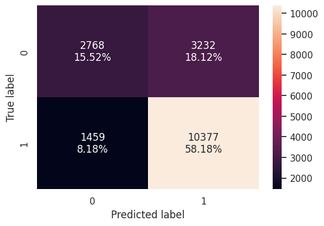

```python
# to view confusion matrix
confusion_matrix_statsmodels(lg2, X_train1, y_train)
```

- True Positives (TP): 10,377 (58.18%)
  - Model predicted the right certified candidates 58.18% of the data.
- False Negatives (FN): 1,459 (8.18%)
  - Model predicted denied candidates when the candidate was certified 8.18% of of the data.
- False Positives (FP): 3,232 (18.12%)
  - Model predicted the candidate would be certified when they were denied for 18.12% of the data.
- True Negatives (TN): 2,768 (15.52%)
  - Model predicted the candidate would be denied when they were actually denied for 15.52% of the data.

```python
#to check performance on X_train1 and y_train
print("Training performance:")
log_reg_model_train_perf = model_performance_classification_statsmodels(lg2, X_train1, y_train)
log_reg_model_train_perf
```

```
Training performance:
```

|  | Accuracy | Recall | Precision | F1 |
| --- | --- | --- | --- | --- |
| 0 | 0.73699 | 0.87673 | 0.76251 | 0.81564 |

- Training Performance:
  - Accuracy: 73.70%
  - Recall: 87.67%
  - Precision: 76.25%
  - F1: 81.56%

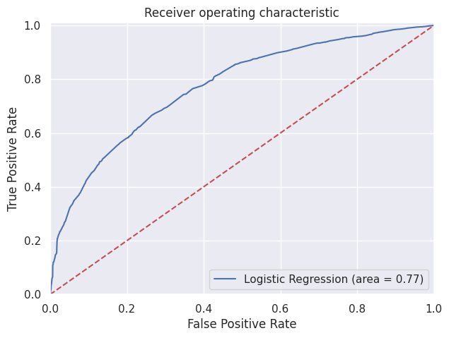

```python
# ROC AUC on training set
logit_roc_auc_train = roc_auc_score(y_train, lg2.predict(X_train1))
fpr, tpr, thresholds = roc_curve(y_train, lg2.predict(X_train1))
plt.figure(figsize=(7, 5))
plt.plot(fpr, tpr, label="Logistic Regression (area = %0.2f)" % logit_roc_auc_train)
plt.plot([0, 1], [0, 1], "r--")
plt.xlim([0.0, 1.0])
plt.ylim([0.0, 1.01])
plt.xlabel("False Positive Rate")
plt.ylabel("True Positive Rate")
plt.title("Receiver operating characteristic")
plt.legend(loc="lower right")
plt.show()
```

```python
# Optimal threshold as per AUC-ROC curve
# The optimal cut off would be where tpr is high and fpr is low
fpr, tpr, thresholds = roc_curve(y_train, lg2.predict(X_train1))

optimal_idx = np.argmax(tpr-fpr)
optimal_threshold_auc_roc = thresholds[optimal_idx]
print(optimal_threshold_auc_roc)
```

```
0.6972487588268409
```

- The optimal threshold pre the AUC ROC is .6972.

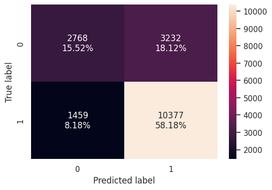

```python
# creating confusion matrix
confusion_matrix_statsmodels(
    lg2, X_train1, y_train
)
```

```python
# checking model performance for this model
log_reg_model_train_perf_threshold_auc_roc = model_performance_classification_statsmodels(
    lg2, X_train1, y_train, threshold=optimal_threshold_auc_roc
)
print("Training performance:")
log_reg_model_train_perf_threshold_auc_roc
```

```
Training performance:
```

|  | Accuracy | Recall | Precision | F1 |
| --- | --- | --- | --- | --- |
| 0 | 0.68900 | 0.66543 | 0.83229 | 0.73957 |

- Training Performance:
  - Accuracy: 68.90%
  - Recall: 66.54%
  - Precision: 83.23%
  - F1: 73.96%
- After identifying the optimal threshold AUC ROC, Recall is 66.54% which provides more reliability.

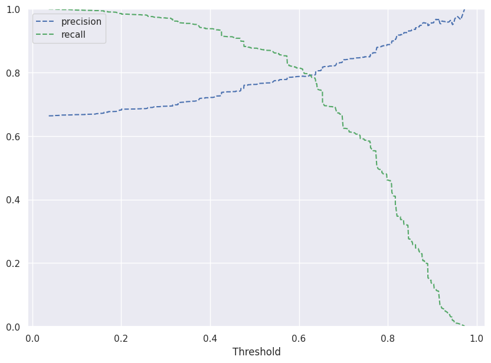

```python
# using precision recall for a better threshold
y_scores = lg2.predict(X_train1)
prec, rec, tre = precision_recall_curve(y_train, y_scores,)


def plot_prec_recall_vs_tresh(precisions, recalls, thresholds):
    plt.plot(thresholds, precisions[:-1], "b--", label="precision")
    plt.plot(thresholds, recalls[:-1], "g--", label="recall")
    plt.xlabel("Threshold")
    plt.legend(loc="upper left")
    plt.ylim([0, 1])


plt.figure(figsize=(10, 7))
plot_prec_recall_vs_tresh(prec, rec, tre)
plt.show()
```

- At the threshold of 0.62, we get balanced recall and precision.

```python
# setting the threshold
optimal_threshold_curve = 0.62
```